# DM polynomials

Valerio Calà

21/8/2019

## FIXED-X Setting

In questo file riassumo il contenuto della lezione di Data Mining riguardante le regressioni polinomiali. Il setting è quello del FIXED-X, i.e. non considero il regressore come una variabile aleatoria e tengo fissi i suoi valori anche per il test set.

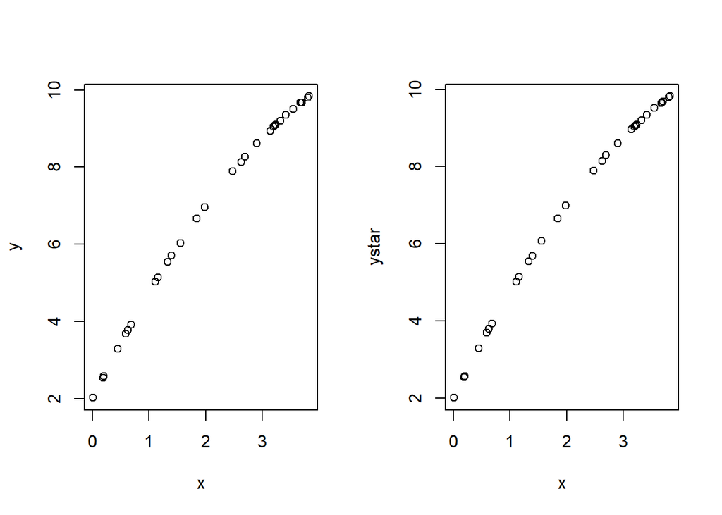

```r
# simulazione del DGP
n <- 30
x <- runif(n, min=0, max=4)
e <- rnorm(n, mean=0, sd=0.01)
f <- function(x) {2 + 3*x - 0.25*x^2}
y <- f(x) + e
estar <- rnorm(n, mean=0, sd=0.01)
ystar <- f(x) + estar
par(mfrow=c(1,2))
plot(x=x, y=y)
plot(x=x, y=ystar)
```

Le coppie di valori (x,y) formano il cosiddetto ‘training set’, mentre le coppie di valori (x, ystar) formano il ‘test set’ (dati da osservare). Il nostro obiettivo è performare bene sul test set, i.e. ottenere un MSEte minimo.

```r
train <- data.frame(x, y)
test <- data.frame(x, ystar)
```

## POLYNOMIALS

Stimo una regressione polinomiale di grado d; non conoscendo la vera forma funzionale di f, ripeto il procedimento per ogni valore di d da 0 a n-1 e scelgo il modello che ha il miglior fit nel test set (MSEte minimo).

```r
ds <- 0:(n-1)
ps <- ds + 1
# funzione per fitting modello polinomiale di grado d
fun <- function(d) if (d==0) lm(y~1, train) else lm(y~poly(x,degree=d, raw=T), train)
fits <- sapply(ds, fun)
```

Adesso che abbiamo stimato tutti gli n modelli, uno per ogni scelta di grado d da 0 a n-1, dimostro che il mean squared error del training set esibisce chiaramente overfitting.

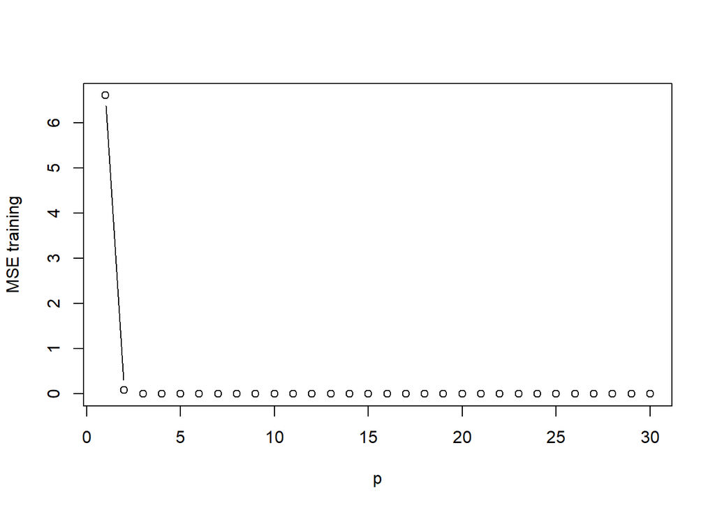

```r
MSEtrain <- unlist(lapply(fits, deviance)) / n
plot(x = ps, y = MSEtrain, xlab='p', ylab='MSE training', type='b')
```

Invece l’andamento dell’MSE nel test set indica il modello polinomiale ottimo, da cui la scelta sul numero di parametri (p = d + 1)

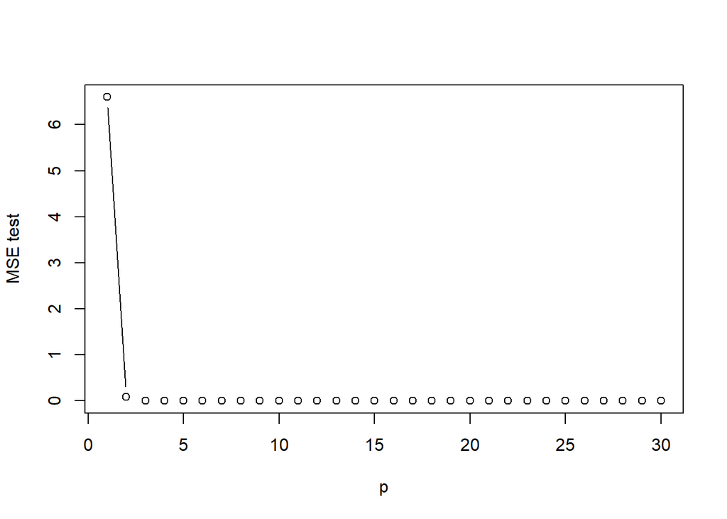

```r
yhats <- lapply(fits, predict)
MSEtest <- unlist(lapply(yhats,
                         function(yhat) mean((ystar - yhat)^2)
                         ))
plot(ps,MSEtest,xlab='p',ylab='MSE test',type='b')
```

```r
# qual è la scelta ottimale?
ps[which.min(MSEtest)]
```

```
## [1] 5
```